# Microbial Informatics

## Lecture 26

Patrick D. Schloss, PhD (microbialinformatics.github.io)  
Department of Microbiology & Immunology

## Announcements

- Homework is due tomorrow
  - Remember to supply code with a knitr document
  - Use `source` to load the code from within knitr
  - Results should be embeded in the text so that if I use `echo=F`, so I can still see what happened
- Final project (due 12/16/2014)
  - Email me your idea by Tuesday
  - Should be a program that others can use to do something useful (I have ideas if you need one)
  - Create a public repository with documentation in README file and license

## Review

[figure not shown]

## Overall algorithm possibilities

- Brute force search for all possible words in grid and compare those to the dictionary
- Brute force search for every word in dictionary in the grid
- A hybrid approach where you build words off of every block and end a search string when it is no longer in the dictionary

## This was (too) hard...

| Algorithm | Time | Time (with data structure population) | Requested Primary Memory |
| --- | --- | --- | --- |
| Full Enumeration | 2,5sec+ | 2,5sec+ | ~6MB |
| Active Dictionary | 150ms | 170ms | ~0MB |
| Branch and Bound | 1ms | 300ms | ~140MB |

- Timings for code written in C (faster than R)
- http://miromannino.com/ruzzle-solver-algorithm/

## Some people take this way too seriously

- It uses the Beta Distribution to choose good, but not too good, words (to avoid all the suspects).
- It applies an istintive human reasoning. In this way, the final word list seems written by an human.
- It determines the current round, to change its behavior.
- Sometimes it draws casual words. In this way it never gets 100% of accuracy.
- It limits the number of words (a casual limit, that varies with the current round).
- It limits the number of points (a casual limit, that varies with the current round).
- Dictionary is limited, only a subset of the complete one.

## Whoa.

[video not shown]

## How I did it

- Brute force search for all possible words in grid seemed most intuitive to me
- Neighbors will be the same regardless of the actual tiles
- Read the matrix in as a string and then convert to a matrix
- Start with 2 letter words and find all possible words
- Use all 2 letter words (2-mers) to get 3 letter words (3-mers), etc.
  - Make sure that you don't reuse letters
  - Do up to 10 letter words (10-mers, not exhaustive!)
  - Keep the path as you go
- Identify overlap between all k-mers and the dictionary

## Preliminaries

```r
# load the dictionary
dictionary <- scan("http://www.freescrabbledictionary.com/sowpods.txt", what="", skip=2, quiet=T)
dictionary <- toupper(dictionary)

# load the board
# BOIA
# RAMD
# TEHA
# IOCR

#convet the board string to a matrix
boardString <- "BOIARAMDTEHAIOCR"
board <- matrix(unlist(strsplit(boardString, "")), nrow=4, byrow=T)
```

## Precompute the neighbors

```r
neighbors <- list()
neighbors[[1]]  <- c(2,5,6)
neighbors[[2]]  <- c(1,3,5,6,7)
neighbors[[3]]  <- c(2,4,6,7,8)
neighbors[[4]]  <- c(3,7,8)
neighbors[[5]]  <- c(1,2,6,9,10)
neighbors[[6]]  <- c(1,2,3,5,7,9,10,11)
neighbors[[7]]  <- c(2,3,4,6,8,10,11,12)
neighbors[[8]]  <- c(3,4,7,11,12)
neighbors[[9]]  <- c(5,6,10,13,14)
neighbors[[10]] <- c(5,6,7,9,11,13,14,15)
neighbors[[11]] <- c(6,7,8,10,12,14,15,16)
neighbors[[12]] <- c(7,8,11,15,16)
neighbors[[13]] <- c(9,10,14)
neighbors[[14]] <- c(9,10,11,13,15)
neighbors[[15]] <- c(10,11,12,14,16)
neighbors[[16]] <- c(11,12,15)
```

## Final all possible 2-mers

- For each of the 16 tiles, make a path and a 2-mer for it and all of its neighbors
- Should be 84 2-mers
- Store paths and words as lists where the top-level entry is the length of the word (i.e. `paths[[2]]` contains the paths for the 2 letter words)

## R

```r
paths <- list()
words <- list()

this.paths <- numeric()
this.words <- character()

for(i in 1:16){
    word <- paste(board[i], board[neighbors[[i]]], sep="")
    new.paths <- cbind(rep(i, length(neighbors[[i]])), neighbors[[i]])
    this.words <- c(this.words, word)
    this.paths <- rbind(this.paths, new.paths)
}
paths[[2]] <- this.paths
words[[2]] <- this.words
n.prev <- length(this.words)
n.prev
```

```
## [1] 84
```

## The 2-mers

```
##  [1] "BR" "BO" "BA" "RB" "RT" "RO" "RA" "RE" "TR" "TI" "TA" "TE" "TO" "IT"
## [15] "IE" "IO" "OB" "OR" "OA" "OI" "OM" "AB" "AR" "AT" "AO" "AE" "AI" "AM"
## [29] "AH" "ER" "ET" "EI" "EA" "EO" "EM" "EH" "EC" "OT" "OI" "OE" "OH" "OC"
## [43] "IO" "IA" "IM" "IA" "ID" "MO" "MA" "ME" "MI" "MH" "MA" "MD" "MA" "HA"
## [57] "HE" "HO" "HM" "HC" "HD" "HA" "HR" "CE" "CO" "CH" "CA" "CR" "AI" "AM"
## [71] "AD" "DI" "DM" "DH" "DA" "DA" "AM" "AH" "AC" "AD" "AR" "RH" "RC" "RA"
```

## What do we know...

- All the 2-mers and their path
- Could now take these and extend them by getting the neigbhor of `paths[[2]][,2]`
- Probably don't need the `for` loop, but we'll leave it for now
- Let's try 3-mers

## R

```r
this.paths <- numeric()
this.words <- character()

for(i in 1:n.prev){
    prev <- paths[[2]][i,]
    nextChar <- neighbors[[prev[2]]]
    goodNeighbors <- nextChar[!nextChar %in% prev]
    n.goodneighbors <- length(goodNeighbors)
    new.paths <- cbind(matrix(rep(prev, n.goodneighbors), nrow=n.goodneighbors, byrow=T), goodNeighbors)
    word <- paste(words[[2]][i], board[goodNeighbors], sep="")
    this.words <- c(this.words, word)
    this.paths <- rbind(this.paths, new.paths)
}
paths[[3]] <- this.paths
words[[3]] <- this.words
n.prev <- length(this.words)
n.prev
```

```
## [1] 408
```

## The 3-mers

```
##   [1] "BRT" "BRO" "BRA" "BRE" "BOR" "BOA" "BOI" "BOM" "BAR" "BAT" "BAO"
##  [12] "BAE" "BAI" "BAM" "BAH" "RBO" "RBA" "RTI" "RTA" "RTE" "RTO" "ROB"
##  [23] "ROA" "ROI" "ROM" "RAB" "RAT" "RAO" "RAE" "RAI" "RAM" "RAH" "RET"
##  [34] "REI" "REA" "REO" "REM" "REH" "REC" "TRB" "TRO" "TRA" "TRE" "TIE"
##  [45] "TIO" "TAB" "TAR" "TAO" "TAE" "TAI" "TAM" "TAH" "TER" "TEI" "TEA"
##  [56] "TEO" "TEM" "TEH" "TEC" "TOI" "TOE" "TOH" "TOC" "ITR" "ITA" "ITE"
##  [67] "ITO" "IER" "IET" "IEA" "IEO" "IEM" "IEH" "IEC" "IOT" "IOE" "IOH"
##  [78] "IOC" "OBR" "OBA" "ORB" "ORT" "ORA" "ORE" "OAB" "OAR" "OAT" "OAE"
##  [89] "OAI" "OAM" "OAH" "OIA" "OIM" "OIA" "OID" "OMA" "OME" "OMI" "OMH"
## [100] "OMA" "OMD" "OMA" "ABR" "ABO" "ARB" "ART" "ARO" "ARE" "ATR" "ATI"
## [111] "ATE" "ATO" "AOB" "AOR" "AOI" "AOM" "AER" "AET" "AEI" "AEO" "AEM"
## [122] "AEH" "AEC" "AIO" "AIM" "AIA" "AID" "AMO" "AME" "AMI" "AMH" "AMA"
## [133] "AMD" "AMA" "AHE" "AHO" "AHM" "AHC" "AHD" "AHA" "AHR" "ERB" "ERT"
## [144] "ERO" "ERA" "ETR" "ETI" "ETA" "ETO" "EIT" "EIO" "EAB" "EAR" "EAT"
## [155] "EAO" "EAI" "EAM" "EAH" "EOT" "EOI" "EOH" "EOC" "EMO" "EMA" "EMI"
```

[output cut: 23 more lines]

## Keep going with 4-mers

```r
this.paths <- numeric()
this.words <- character()

for(i in 1:n.prev){
    prev <- paths[[3]][i,]
    nextChar <- neighbors[[prev[3]]]
    goodNeighbors <- nextChar[!nextChar %in% prev]
    n.goodneighbors <- length(goodNeighbors)
    new.paths <- cbind(matrix(rep(prev, n.goodneighbors), nrow=n.goodneighbors, byrow=T), goodNeighbors)
    word <- paste(words[[3]][i], board[goodNeighbors], sep="")
    this.words <- c(this.words, word)
    this.paths <- rbind(this.paths, new.paths)
}
paths[[4]] <- this.paths
words[[4]] <- this.words
n.prev <- length(this.words)
```

## The 4-mers

```
##    [1] "BRTI" "BRTA" "BRTE" "BRTO" "BROA" "BROI" "BROM" "BRAT" "BRAO"
##   [10] "BRAE" "BRAI" "BRAM" "BRAH" "BRET" "BREI" "BREA" "BREO" "BREM"
##   [19] "BREH" "BREC" "BORT" "BORA" "BORE" "BOAR" "BOAT" "BOAE" "BOAI"
##   [28] "BOAM" "BOAH" "BOIA" "BOIM" "BOIA" "BOID" "BOMA" "BOME" "BOMI"
##   [37] "BOMH" "BOMA" "BOMD" "BOMA" "BART" "BARO" "BARE" "BATR" "BATI"
##   [46] "BATE" "BATO" "BAOR" "BAOI" "BAOM" "BAER" "BAET" "BAEI" "BAEO"
##   [55] "BAEM" "BAEH" "BAEC" "BAIO" "BAIM" "BAIA" "BAID" "BAMO" "BAME"
##   [64] "BAMI" "BAMH" "BAMA" "BAMD" "BAMA" "BAHE" "BAHO" "BAHM" "BAHC"
##   [73] "BAHD" "BAHA" "BAHR" "RBOA" "RBOI" "RBOM" "RBAT" "RBAO" "RBAE"
##   [82] "RBAI" "RBAM" "RBAH" "RTIE" "RTIO" "RTAB" "RTAO" "RTAE" "RTAI"
##   [91] "RTAM" "RTAH" "RTEI" "RTEA" "RTEO" "RTEM" "RTEH" "RTEC" "RTOI"
##  [100] "RTOE" "RTOH" "RTOC" "ROBA" "ROAB" "ROAT" "ROAE" "ROAI" "ROAM"
##  [109] "ROAH" "ROIA" "ROIM" "ROIA" "ROID" "ROMA" "ROME" "ROMI" "ROMH"
##  [118] "ROMA" "ROMD" "ROMA" "RABO" "RATI" "RATE" "RATO" "RAOB" "RAOI"
##  [127] "RAOM" "RAET" "RAEI" "RAEO" "RAEM" "RAEH" "RAEC" "RAIO" "RAIM"
```

[output cut: 181 more lines]

## Could keep going, but...

- We will now have a lot of repeated code
- The only thing that changes is the number we use to index the previous k-mer length and the current k-mer length
- That for loop is bothersome
- Let's abstract this to make a function

```r
getNext <- function(paths, words, new.length){
    length <- new.length - 1
    n.prev <- length(words[[length]])
    this.paths <- numeric()
    this.words <- character()

    for(i in 1:n.prev){
        prev <- paths[[length]][i,]
        nextChar <- neighbors[[prev[length]]]
        goodNeighbors <- nextChar[!nextChar %in% prev]
        if(length(goodNeighbors)>0){
            n.goodneighbors <- length(goodNeighbors)
            new.paths <- cbind(matrix(rep(prev, n.goodneighbors), nrow=n.goodneighbors, byrow=T), goodNeighbors)
            word <- paste(words[[length]][i], board[goodNeighbors], sep="")
            this.words <- c(this.words, word)
            this.paths <- rbind(this.paths, new.paths)
        }
    }
    return(list(path=this.paths, word=this.words))
}
```

## The 5-mers

```r
update <- getNext(paths, words, 5)
paths[[5]] <- update$path
words[[5]] <- update$word
```

```
##    [1] "BRTIE" "BRTIO" "BRTAO" "BRTAE" "BRTAI" "BRTAM" "BRTAH" "BRTEI"
##    [9] "BRTEA" "BRTEO" "BRTEM" "BRTEH" "BRTEC" "BRTOI" "BRTOE" "BRTOH"
##   [17] "BRTOC" "BROAT" "BROAE" "BROAI" "BROAM" "BROAH" "BROIA" "BROIM"
##   [25] "BROIA" "BROID" "BROMA" "BROME" "BROMI" "BROMH" "BROMA" "BROMD"
##   [33] "BROMA" "BRATI" "BRATE" "BRATO" "BRAOI" "BRAOM" "BRAET" "BRAEI"
##   [41] "BRAEO" "BRAEM" "BRAEH" "BRAEC" "BRAIO" "BRAIM" "BRAIA" "BRAID"
##   [49] "BRAMO" "BRAME" "BRAMI" "BRAMH" "BRAMA" "BRAMD" "BRAMA" "BRAHE"
##   [57] "BRAHO" "BRAHM" "BRAHC" "BRAHD" "BRAHA" "BRAHR" "BRETI" "BRETA"
##   [65] "BRETO" "BREIT" "BREIO" "BREAT" "BREAO" "BREAI" "BREAM" "BREAH"
##   [73] "BREOT" "BREOI" "BREOH" "BREOC" "BREMO" "BREMA" "BREMI" "BREMH"
##   [81] "BREMA" "BREMD" "BREMA" "BREHA" "BREHO" "BREHM" "BREHC" "BREHD"
##   [89] "BREHA" "BREHR" "BRECO" "BRECH" "BRECA" "BRECR" "BORTI" "BORTA"
##   [97] "BORTE" "BORTO" "BORAT" "BORAE" "BORAI" "BORAM" "BORAH" "BORET"
##  [105] "BOREI" "BOREA" "BOREO" "BOREM" "BOREH" "BOREC" "BOART" "BOARE"
##  [113] "BOATR" "BOATI" "BOATE" "BOATO" "BOAER" "BOAET" "BOAEI" "BOAEO"
```

[output cut: 824 more lines]

## Put it together

```r
getKMers <- function(maxKmer=10){
    paths <- list()
    words <- list()
    paths[[1]] <- matrix(1:16, ncol=1)
    words[[1]] <- matrix(as.vector(board), ncol=1)

    for(i in 2:maxKmer){
        update <- getNext(paths, words, i)
        paths[[i]] <- update$path
        words[[i]] <- update$word
    }
    return(list(path=paths, word=words))
}
```

## Run it... ... slow

```r
start <- proc.time()
final <- getKMers(7)
end <- proc.time()
end-start
```

```
##    user  system elapsed
##  67.907   7.296  75.270
```

## This gets out of hand fast...

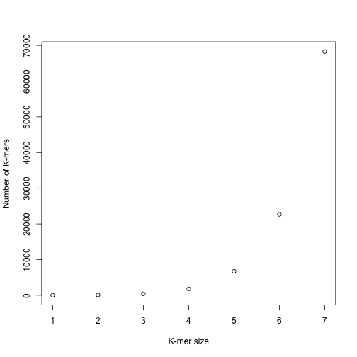

## About those `for` loops...

```r
getNext <- function(paths, words, new.length){
    length <- new.length - 1
    n.prev <- length(words[[length]])
    this.paths <- numeric()
    this.words <- character()

    for(i in 1:n.prev){
        prev <- paths[[length]][i,]
        nextChar <- neighbors[[prev[length]]]
        goodNeighbors <- nextChar[!nextChar %in% prev]
        if(length(goodNeighbors)>0){
            n.goodneighbors <- length(goodNeighbors)
            new.paths <- cbind(matrix(rep(prev, n.goodneighbors), nrow=n.goodneighbors, byrow=T), goodNeighbors)
            word <- paste(words[[length]][i], board[goodNeighbors], sep="")
            this.words <- c(this.words, word)
            this.paths <- rbind(this.paths, new.paths)
        }
    }
    return(list(path=this.paths, word=this.words))
}
```

## Let's define a new function

- Take contents of `for` loop from `getNext` and use it to make a function `cat` (conCATenate)
- Modify `getNext` to create `getNext2`, which calls `cat`
- Also, we're getting nailed on recreating a new list every time we add a new k-mer. Let's drop the word list and create it at the end when we have all of the paths

## New `cat` function

```r
cat <- function(i, length, paths){
    prev <- paths[[length]][i,]
    nextChar <- neighbors[[prev[length]]]
    goodNeighbors <- nextChar[!nextChar %in% prev]
    if(length(goodNeighbors)>0){
        n.goodneighbors <- length(goodNeighbors)
        new.paths <- cbind(matrix(rep(prev, n.goodneighbors), nrow=n.goodneighbors, byrow=T), goodNeighbors)
        return(new.paths)
    } else{
        return(NULL);  #needed in case there are no neighbors remaining
    }
}
```

## New `getNext2` function

```r
getNext2 <- function(new.length, paths){
    length <- new.length - 1
    n.prev <- nrow(paths[[length]])
    path.list <- sapply(1:n.prev, cat, length, paths)  #<-- This replaces for loop
    return(do.call(rbind, path.list))
}
```

## Try again...

```r
start <- proc.time()

paths <- list()

paths[[1]] <- matrix(1:16, ncol=1)
for(l in 2:10){
    paths[[l]] <- getNext2(l, paths)
}

end <- proc.time()
end-start
```

```
##    user  system elapsed
##  22.720   0.247  22.973
```

- The lingering `for` loop is still a problem

## Now we need to translate our paths to words

- Let's look an an example (ignore the "goodNeighbors")...

```r
paths[[9]][1,]
```

```
##
##             1             2             3             4             7
##                                           goodNeighbors
##             6             5             9            10
```

```r
board[paths[[9]][1,]]
```

```
## [1] "B" "R" "T" "I" "E" "A" "O" "I" "M"
```

```r
paste(board[paths[[9]][1,]], collapse="")
```

```
## [1] "BRTIEAOIM"
```

## Think about the data structure we have

- It's a list where each value of paths is a different k-mer size
- Within each k-mer is a matrix of n rows and k columns
- To tranlate the entire list we need to...
  - Translate each matrix
  - Translate each row of each matrix
- Then glue it all together as a big vector of words

## R

```r
translate.vector <- function(x){
    paste(board[x], collapse="")
}

translate.matrix <- function(x){
    apply(x, 1, translate.vector)
}

words <- list()
words <- lapply(paths, translate.matrix)
words.vector <- unlist(words)
```

## What do these words look like?

```r
length(words.vector)
```

```
## [1] 1626160
```

```r
sort(words.vector)[1:100]
```

```
##   [1] "A"          "A"          "A"          "AB"         "ABO"
##   [6] "ABOI"       "ABOIA"      "ABOIAD"     "ABOIADA"    "ABOIADAC"
##  [11] "ABOIADACE"  "ABOIADACEH" "ABOIADACEI" "ABOIADACEM" "ABOIADACEO"
##  [16] "ABOIADACER" "ABOIADACET" "ABOIADACH"  "ABOIADACHE" "ABOIADACHM"
##  [21] "ABOIADACHO" "ABOIADACHR" "ABOIADACO"  "ABOIADACOE" "ABOIADACOH"
##  [26] "ABOIADACOI" "ABOIADACOT" "ABOIADACR"  "ABOIADACRH" "ABOIADAH"
##  [31] "ABOIADAHC"  "ABOIADAHCE" "ABOIADAHCO" "ABOIADAHCR" "ABOIADAHE"
##  [36] "ABOIADAHEC" "ABOIADAHEI" "ABOIADAHEM" "ABOIADAHEO" "ABOIADAHER"
##  [41] "ABOIADAHET" "ABOIADAHM"  "ABOIADAHME" "ABOIADAHO"  "ABOIADAHOC"
##  [46] "ABOIADAHOE" "ABOIADAHOI" "ABOIADAHOT" "ABOIADAHR"  "ABOIADAHRC"
##  [51] "ABOIADAM"   "ABOIADAME"  "ABOIADAMEC" "ABOIADAMEH" "ABOIADAMEI"
##  [56] "ABOIADAMEO" "ABOIADAMER" "ABOIADAMET" "ABOIADAMH"  "ABOIADAMHC"
##  [61] "ABOIADAMHE" "ABOIADAMHO" "ABOIADAMHR" "ABOIADAR"   "ABOIADARC"
##  [66] "ABOIADARCE" "ABOIADARCH" "ABOIADARCO" "ABOIADARH"  "ABOIADARHC"
##  [71] "ABOIADARHE" "ABOIADARHM" "ABOIADARHO" "ABOIADH"    "ABOIADHA"
##  [76] "ABOIADHAC"  "ABOIADHACE" "ABOIADHACO" "ABOIADHACR" "ABOIADHAM"
##  [81] "ABOIADHAME" "ABOIADHAR"  "ABOIADHARC" "ABOIADHC"   "ABOIADHCA"
##  [86] "ABOIADHCAM" "ABOIADHCAR" "ABOIADHCE"  "ABOIADHCEI" "ABOIADHCEM"
##  [91] "ABOIADHCEO" "ABOIADHCER" "ABOIADHCET" "ABOIADHCO"  "ABOIADHCOE"
##  [96] "ABOIADHCOI" "ABOIADHCOT" "ABOIADHCR"  "ABOIADHCRA" "ABOIADHE"
```

## A lot of that is jibberish

- Need to cross reference our 1626160 words with the dictionary

```r
overlap <- intersect(words.vector, dictionary)

length(overlap)
```

```
## [1] 329
```

```r
sort(overlap)[1:100]
```

```
##   [1] "AB"       "ABO"      "ABOMA"    "ABORE"    "ABORT"    "ACE"
##   [7] "ACER"     "ACERB"    "ACETA"    "ACETAMID" "ACH"      "ACHE"
##  [13] "AD"       "AE"       "AERO"     "AH"       "AHA"      "AHEM"
##  [19] "AI"       "AIA"      "AID"      "AIM"      "AIMER"    "AM"
##  [25] "AMA"      "AMAH"     "AMATE"    "AMI"      "AMIA"     "AMID"
##  [31] "AMORET"   "AMORT"    "AR"       "ARB"      "ARC"      "ARCH"
##  [37] "ARCHAEI"  "ARCHEI"   "ARCHER"   "ARCO"     "ARE"      "ARECA"
##  [43] "ARET"     "ARHAT"    "AROID"    "AROMA"    "ART"      "ARTI"
##  [49] "AT"       "ATE"      "ATOC"     "BA"       "BAH"      "BAHADA"
##  [55] "BAM"      "BAR"      "BARE"     "BAT"      "BATE"     "BO"
##  [61] "BOA"      "BOAR"     "BOART"    "BOAT"     "BOATER"   "BOATIE"
##  [67] "BOI"      "BOMA"     "BOR"      "BORA"     "BORATE"   "BORE"
##  [73] "BORT"     "BRA"      "BRAE"     "BRAHMA"   "BRAID"    "BRAME"
##  [79] "BRAT"     "BREAM"    "BRECHAM"  "BREI"     "BRO"      "BROMATE"
##  [85] "BROME"    "BROMID"   "CAD"      "CADI"     "CAM"      "CAMA"
##  [91] "CAME"     "CAMEO"    "CAMERA"   "CAMO"     "CAR"      "CERO"
##  [97] "CERT"     "CH"       "CHA"      "CHAD"
```

## Recall how we might sort these by length?

```
##   [1] "ACETAMID" "RACEMOID" "BROMATE"  "BRECHAM"  "TOHEROA"  "MARCHER"
##   [7] "HAEMOID"  "DIORAMA"  "ARCHAEI"  "RADIATE"  "BROMID"   "BRAHMA"
##  [13] "BORATE"   "BOATIE"   "BOATER"   "BAHADA"   "RAMADA"   "RETAMA"
##  [19] "TOCHER"   "OMERTA"   "AMORET"   "IMARET"   "MATIER"   "MACHER"
##  [25] "HAMADA"   "HEMOID"   "HAMATE"   "CHARET"   "CAMERA"   "DACOIT"
##  [31] "ARCHER"   "ARCHEI"   "RAMATE"   "RACHET"   "BROME"    "BRAID"
##  [37] "BRAME"    "BREAM"    "BOART"    "ROATE"    "ROMEO"    "RATIO"
##  [43] "RAMET"    "REHAB"    "TREMA"    "TABOR"    "TAMER"    "TERAI"
##  [49] "ORATE"    "OATER"    "ABORT"    "ABORE"    "ABOMA"    "AROID"
##  [55] "AROMA"    "ARECA"    "AIMER"    "AMORT"    "OCHER"    "MORAT"
##  [61] "MORAE"    "MATER"    "MAHOE"    "METRO"    "MACER"    "MACHE"
##  [67] "MACHO"    "MARCH"    "HAREM"    "HATER"    "HAOMA"    "HEART"
##  [73] "COHAB"    "CHART"    "CHARE"    "CHERT"    "CHEAT"    "CHEMO"
##  [79] "CHOTA"    "CAMEO"    "CRAME"    "AMATE"    "DIMER"    "DHOTI"
##  [85] "DAMAR"    "DACHA"    "ACERB"    "ACETA"    "ARHAT"    "RACER"
```

[output cut: 40 more lines]

## Now we need to recover the paths

```r
getPath <- function(word){
    wordLength <- nchar(word)
    hit <- which(words[[wordLength]] == word)
    path <- paths[[wordLength]][hit,]
    if(length(hit) > 1){
        path.strings <- apply(path, 1, paste, collapse=",")
        path.strings <- paste(path.strings, collapse=" / ")
    } else {
        path.strings <- paste(path, collapse=",")
    }
    return(path.strings)
}

sapply(overlap, getPath)
```

```
                                                       BO
                                                    "1,5"
                                                       BA
                                                    "1,6"
                                                       RE
                                                    "2,7"
                                                       TI
                                                    "3,4"
                                                       TA
                                                    "3,6"
                                                       TE
                                                    "3,7"
                                                       TO
                                                    "3,8"
                                                       IT
                                                    "4,3"
                                                       IO
                                              "4,8 / 9,5"
                                                       OB
                                                    "5,1"
                                                       OR
                                                    "5,2"
                                                       OI
                                              "5,9 / 8,4"
                                                       OM
                                                   "5,10"
                                                       AB
                                                    "6,1"
                                                       AR
                                            "6,2 / 15,16"
                                                       AT
                                                    "6,3"
                                                       AE
                                                    "6,7"
                                                       AI
                                             "6,9 / 13,9"
                                                       AM
                                   "6,10 / 13,10 / 15,10"
                                                       AH
                                           "6,11 / 15,11"
                                                       ER
                                                    "7,2"
                                                       ET
                                                    "7,3"
                                                       EA
                                                    "7,6"
                                                       EM
                                                   "7,10"
                                                       EH
                                                   "7,11"
                                                       OE
                                                    "8,7"
                                                       OH
                                                   "8,11"
                                                       ID
                                                   "9,14"
                                                       MO
                                                   "10,5"
                                                       MA
                                   "10,6 / 10,13 / 10,15"
                                                       ME
                                                   "10,7"
                                                       MI
                                                   "10,9"
                                                       HA
                                           "11,6 / 11,15"
                                                       HE
                                                   "11,7"
                                                       HO
                                                   "11,8"
                                                       HM
                                                  "11,10"
                                                       CH
                                                  "12,11"
                                                       AD
                                          "13,14 / 15,14"
                                                       DI
                                                   "14,9"
                                                       DA
                                          "14,13 / 14,15"
                                                      BRO
                                                  "1,2,5"
                                                      BRA
                                                  "1,2,6"
                                                      BOR
                                                  "1,5,2"
                                                      BOA
                                                  "1,5,6"
                                                      BOI
                                                  "1,5,9"
                                                      BAR
                                                  "1,6,2"
                                                      BAT
                                                  "1,6,3"
                                                      BAM
                                                 "1,6,10"
                                                      BAH
                                                 "1,6,11"
                                                      ROB
                                                  "2,5,1"
                                                      ROM
                                                 "2,5,10"
                                                      RAT
                                                  "2,6,3"
                                                      RAI
                                                  "2,6,9"
                                                      RAM
                                      "2,6,10 / 16,15,10"
                                                      RAH
                                      "2,6,11 / 16,15,11"
                                                      RET
                                                  "2,7,3"
                                                      REI
                                                  "2,7,4"
                                                      REO
                                                  "2,7,8"
                                                      REM
                                                 "2,7,10"
                                                      REH
                                                 "2,7,11"
                                                      REC
                                                 "2,7,12"
                                                      TIE
                                                  "3,4,7"
                                                      TAB
                                                  "3,6,1"
                                                      TAR
                                                  "3,6,2"
                                                      TAO
                                                  "3,6,5"
                                                      TAE
                                                  "3,6,7"
                                                      TAI
                                                  "3,6,9"
                                                      TAM
                                                 "3,6,10"
                                                      TEA
                                                  "3,7,6"
                                                      TEC
                                                 "3,7,12"
                                                      TOE
                                                  "3,8,7"
                                                      TOC
                                                 "3,8,12"
                                                      ITA
                                                  "4,3,6"
                                                      OBA
                                                  "5,1,6"
                                                      ORB
                                                  "5,2,1"
                                                      ORT
                                                  "5,2,3"
                                                      ORA
                                                  "5,2,6"
                                                      ORE
                                                  "5,2,7"
                                                      OAR
                                                  "5,6,2"
                                                      OAT
                                                  "5,6,3"
                                                      ABO
                                                  "6,1,5"
                                                      ARB
                                                  "6,2,1"
                                                      ART
                                                  "6,2,3"
                                                      ARE
                                                  "6,2,7"
                                                      ATE
                                                  "6,3,7"
                                                      AIM
                                       "6,9,10 / 13,9,10"
                                                      AIA
                                        "6,9,13 / 13,9,6"
                                                      AID
                                       "6,9,14 / 13,9,14"
                                                      AMI
                             "6,10,9 / 13,10,9 / 15,10,9"
                                                      AMA
```